# Biostat 212a Homework 1

Due Jan 23, 2024 @ 11:59PM

Author

Jiyin (Jenny) Zhang and 606331859

Published

March 30, 2024

## 1 Filling gaps in lecture notes (10pts)

Consider the regression model
$$Y = f(X) + \epsilon,$$
where $\operatorname{E}(\epsilon) = 0$.

### 1.1 Optimal regression function

Show that the choice
$$f_{\text{opt}}(X) = \operatorname{E}(Y | X)$$
minimizes the mean squared prediction error
$$\operatorname{E}\{[Y - f(X)]^2\},$$
where the expectations averages over variations in both $X$ and $Y$. (Hint: condition on $X$.)

**Answer:**

$$\begin{align*}
MSE=\operatorname{E}\{\{[Y - f(X)]^2\} &= \operatorname{E}\ {\{\operatorname{E}\{[Y - f(X)]^2 | X\} }\}\\
&= \operatorname{E}\ {\{\operatorname{E}\{Y^2 - 2*Y*f(X) + [f(x)]^2 | X\} }\} \\
&= \operatorname{E}\ {\{\operatorname{E}(Y^2 | X) - 2*f(X)*\operatorname{E}(Y | X) + [f(x)]^2\} } \\
\end{align*}$$

To get the minimum, we take the derivative of the inner expectation with respect to f(X) and set it to 0.

$$\begin{align*}
\frac{d\operatorname{E}(Y^2 | X) - 2*f(X)*\operatorname{E}(Y | X) + [f(x)]^2} {df(x)}= 0 - 2*\operatorname{E}(Y|X) + 2*f(X) = 0 \\
f(X) = \operatorname{E}(Y|X) = f_{\text{opt}}(X)
\end{align*}$$

### 1.2 Bias-variance trade-off

Given an estimate $\hat f$ of $f$, show that the test error at a $x_0$ can be decomposed as
$$\operatorname{E}\{[y_0 - \hat f(x_0)]^2\} = \underbrace{\operatorname{Var}(\hat f(x_0)) + [\operatorname{Bias}(\hat f(x_0))]^2}_{\text{MSE of } \hat f(x_0) \text{ for estimating } f(x_0)} + \underbrace{\operatorname{Var}(\epsilon)}_{\text{irreducible}},$$
where the expectation averages over the variability in $y_0$ and $\hat f$.

**Answer:**
$$\begin{align*}
\operatorname{E}\{[y_0 - \hat f(x_0)]^2\} &= \operatorname{E}\{[ \hat f(x_0) - y_0 ]^2 \}\\
&= \operatorname{E}\{[ \hat f(x_0) - [ f(x_0) + \epsilon ]]^2\} \\
&= \operatorname{E}\{[ \hat f(x_0) - f(x_0) - \epsilon ]^2\} \\
&= \operatorname{E}\{[ \hat f(x_0) - f(x_0) ]^2\} + \operatorname{E}( \epsilon^2 ) - 2*\operatorname{E}\{[ \hat f(x_0) - f(x_0) ]*\epsilon\} \\
&= \{\operatorname{E}[ \hat f(x_0) - f(x_0) ]\}^2 + Var[ \hat f(x_0) - f(x_0) ]+ [\operatorname{E}( \epsilon ) ]^2 + Var( \epsilon ) - 2*\operatorname{E}\{[ \hat f(x_0) ]- f(x_0) \}*\operatorname{E}(\epsilon) \\
&= \{\operatorname{E}[ \hat f(x_0) ]- f(x_0) \}^2 +Var[ \hat f(x_0) ] + 0 + Var( \epsilon ) - 0 \\
&= \{Bias[ \hat f(x_0) ]\}^2 +Var[ \hat f(x_0) ] + Var( \epsilon ) \\
\end{align*}$$

## 2 ISL Exercise 2.4.3 (10pts)

**(a)** Provide a sketch of typical (squared) bias, variance, training error, test error, and Bayes (or irreducible) error curves, on a single plot, as we go from less flexible statistical learning methods towards more flexible approaches. The x-axis should represent the amount of flexibility in the method, and the y-axis should represent the values for each curve. There should be five curves. Make sure to label each one.

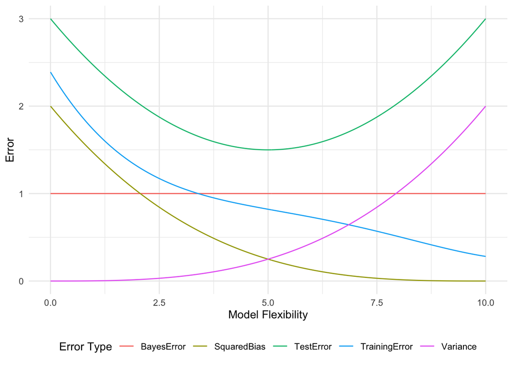

```r
# Install and load necessary packages
library(ggplot2)
library(extrafont)
library(tidyr)


# Create a sequence of values for x
x <- seq(0, 10, 0.02)

# Define functions for squared bias, variance, training error, test error, and Bayes error
squared_bias <- function(x) { 0.002 * (-x + 10)^3 }
variance <- function(x) { 0.002 * x^3 }
training_error <- function(x) { 2.38936 - 0.825077 * x + 0.176655 * x^2 - 0.0182319 * x^3 + 0.00067091 * x^4 }
test_error <- function(x) { 3 - 0.6 * x + 0.06 * x^2 }
bayes_error <- function(x) { x + 1 - x }

# Compute the values for each function
bias_values <- squared_bias(x)
variance_values <- variance(x)
training_error_values <- training_error(x)
test_error_values <- test_error(x)
bayes_error_values <- bayes_error(x)

# Create a plot
#plt <- ggplot() +
#  geom_line(aes(x = x, y = squared_bias(x), color="Squared Bias"), linetype = "solid", size = 1) +
#  geom_line(aes(x = x, y = variance(x), color="Variance"), linetype = "solid", size = 1) +
#  geom_line(aes(x = x, y = training_error(x), color="Training Error"), linetype = "solid", size = 1) +
#  geom_line(aes(x = x, y = test_error(x), color="Test Error"), linetype = "solid", size = 1) +
#  geom_line(aes(x = x, y = bayes_error(x), color="Bayes Error"), linetype = "solid", size = 1) +
#  labs(x = "Model flexibility", y="Values for Each Curve", color = "Curve Type") +

#  scale_color_manual(
#    values = c("Squared Bias" = "red", "Variance" = "blue", "Training Error" = "green", "Test Error" = "purple", "Bayes Error" = "orange"),
#    labels = c("Squared Bias", "Variance", "Training Error", "Test Error", "Bayes Error")
#  ) +
#  guides(color = guide_legend(title = "Curve Type", override.aes = list(shape = NA))) +
#  theme(legend.position = "upper.center", legend.key = element_blank(), legend.title = element_text(size = 12, face = "bold")

# Combine the data into a data frame for ggplot2
data <- data.frame(
  x = x,
  SquaredBias = bias_values,
  Variance = variance_values,
  TrainingError = training_error_values,
  TestError = test_error_values,
  BayesError = bayes_error_values
)

# Use pivot_longer from tidyr to reshape the data
data_long <- pivot_longer(data, cols = -x, names_to = 'ErrorType', values_to = 'Value')

# Plot the data using ggplot2
plt <- ggplot(data_long, aes(x = x, y = Value, color = ErrorType)) +
  geom_line() +
  labs(x = 'Model Flexibility', y = 'Error', color = 'Error Type') +
  theme_minimal() +
  theme(legend.position = "bottom")
# Display the plot
plt
```

**(b)**

**Squared bias:** This is the error in our model introduced by the difference of our approximation and the true underlying function. A more flexible model will be increasingly similar, and the squared bias therefore diminshes as the flexibility increases. (It might even reach zero if for example the underlying function is a polynomial and by increasing the flexibility at a certain point we include the polynomials of this degree in our hypothesis space.)

**Variance:** In the limit of a model with no flexibility the variance will be zero, since the model fit will be independent of the data. As the flexibility increases the variance will increase as well since the noise in a particular training set will correspondingly captured by the model. The curve described by the variance is an monotonically increasing function of the flexibility of the model.

**Training error:** The training error is given by the average (squared) difference between the predictions of the model and the observations. If a model if very unflexible this can be quite high, but as the flexibility increases this difference will decrease. If we consider polynomials for example increasing the flexibility of the model might mean increasing the degree of the polynomial to be fitted. The additional degrees of freedom will decrease the average difference and reduce the training error.

**Test error:** Ths expected test error is given by the formula: Variance + Bias + Bayes error, all of which are non-negative. The Bayes error is constant and a lower bound for the test error. The test error has a minimum at an intermediate level of flexibility: not too flexible, so that the variance does not dominate, and not too inflexible, so that the squared bias is not too high. The plot of the test error thus resembles sort of an upward (deformed) parabola: high for unflexible models, decreasing as flexibility increases until it reaches a minimum. Then the variance starts to dominate and the test error starts increasing. The distance between this minimum and the Bayes irreducible error gives us an idea of how well the best function in the hypothesis space will fit.

**Bayes error:** This term is constant since by definition it does not depend on X and therefore on the flexibility of the model.

## 3 ISL Exercise 2.4.4 (10pts)

**(a)** **Classification:**

- **Email Spam Detection:**

Response Variable: Whether an email is spam or not (binary classification).

Predictors: Features extracted from the email content, sender information, and other metadata.

Goal: Prediction. The goal is to accurately classify emails as spam or non-spam to filter unwanted messages and protect users from phishing or malicious content.

- **Breast Cancer Detection:**

Response Variable: Whether a breast tumor is malignant or benign (binary classification).

Predictors: Various medical features such as tumor size, shape, and texture extracted from mammograms or biopsies.

Goal: Inference and Prediction. The goal is to infer the likelihood of a tumor being malignant based on the provided features. Additionally, prediction is crucial for assisting medical professionals in making decisions about treatment.

- **Credit Scoring:**

Response Variable: Whether a loan applicant is likely to default on a loan (binary classification).

Predictors: Financial and personal information of the loan applicant, including credit score, income, debt, and employment status.

Goal: Prediction. The goal is to predict the creditworthiness of an applicant to make informed decisions about loan approvals. This application helps financial institutions manage risk and optimize lending practices.

**(b)** **Regression:**

- **House Price Prediction:**

Response Variable: The selling price of a house (continuous variable).

Predictors: Features such as the size of the house, number of bedrooms, location, proximity to amenities, and other relevant factors.

Goal: Prediction. The goal is to predict the selling price of a house based on its features, allowing real estate professionals and potential buyers/sellers to make informed decisions.

- **Sales Forecasting:**

Response Variable: Sales volume or revenue (continuous variable).

Predictors: Historical sales data, marketing expenses, seasonality, economic indicators, and other relevant factors.

Goal: Prediction. The goal is to forecast future sales based on historical trends and external factors. This helps businesses optimize inventory, plan marketing strategies, and allocate resources effectively.

- **Educational Performance Prediction:**

Response Variable: Academic performance scores (continuous variable).

Predictors: Variables such as study hours, attendance, previous grades, socio-economic background, and learning style.

Goal: Prediction and Inference. The goal is to predict students’ academic performance based on various factors. Additionally, regression analysis may be used to infer the strength and direction of the relationships between predictors and academic outcomes, aiding in educational research.

**(c)** **Cluster:**

- **Customer Segmentation in Marketing:**

Application: Businesses often use cluster analysis to segment their customer base into distinct groups based on purchasing behavior, demographics, or other relevant features.

- **Healthcare Patient Stratification:**

Application: In healthcare, cluster analysis can be applied to group patients with similar medical histories, genetic profiles, or responses to treatments.

- **Document Categorization in Text Mining:**

Application: Cluster analysis can be applied to categorize documents or texts based on their content and language patterns.

## 4 ISL Exercise 2.4.10 (30pts)

Your can read in the `boston` data set directly from url https://raw.githubusercontent.com/ucla-biostat-212a/2024winter/master/slides/data/Boston.csv. A documentation of the `boston` data set is [here](https://www.rdocumentation.org/packages/ISLR2/versions/1.3-2/topics/Boston).

**R**

```r
library(tidyverse)
Boston <- read_csv("https://raw.githubusercontent.com/ucla-biostat-212a/2024winter/master/slides/data/Boston.csv", col_select = -1) %>%
  print(width = Inf)
```

```
# A tibble: 506 × 13
      crim    zn indus  chas   nox    rm   age   dis   rad   tax ptratio lstat
     <dbl> <dbl> <dbl> <dbl> <dbl> <dbl> <dbl> <dbl> <dbl> <dbl>   <dbl> <dbl>
 1 0.00632  18    2.31     0 0.538  6.58  65.2  4.09     1   296    15.3  4.98
 2 0.0273    0    7.07     0 0.469  6.42  78.9  4.97     2   242    17.8  9.14
 3 0.0273    0    7.07     0 0.469  7.18  61.1  4.97     2   242    17.8  4.03
 4 0.0324    0    2.18     0 0.458  7.00  45.8  6.06     3   222    18.7  2.94
 5 0.0690    0    2.18     0 0.458  7.15  54.2  6.06     3   222    18.7  5.33
 6 0.0298    0    2.18     0 0.458  6.43  58.7  6.06     3   222    18.7  5.21
 7 0.0883   12.5  7.87     0 0.524  6.01  66.6  5.56     5   311    15.2 12.4
 8 0.145    12.5  7.87     0 0.524  6.17  96.1  5.95     5   311    15.2 19.2
 9 0.211    12.5  7.87     0 0.524  5.63 100    6.08     5   311    15.2 29.9
10 0.170    12.5  7.87     0 0.524  6.00  85.9  6.59     5   311    15.2 17.1
    medv
   <dbl>
 1  24
 2  21.6
 3  34.7
 4  33.4
 5  36.2
 6  28.7
 7  22.9
 8  27.1
 9  16.5
10  18.9
# ℹ 496 more rows
```

**(a)**

```r
dim(Boston)
```

```
[1] 506  13
```

- 506 rows of suburbs of Boston and 13 columns of predictors.

**(b)**

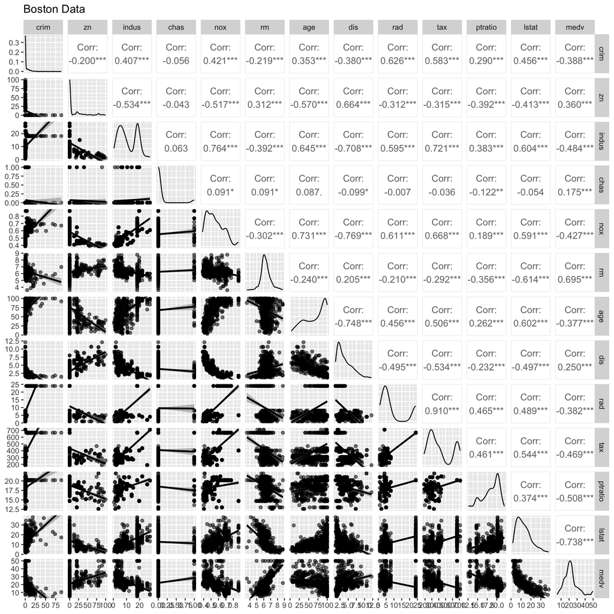

```r
library(GGally) # ggpairs function
selected_columns <- c("crim", "nox", "dis", "tax", "medv")
ggpairs(
  data = Boston,
  mapping = aes(alpha = 0.25),
  lower = list(continuous = "smooth")
  ) +
  labs(title = "Boston Data")
```

- `crim` seems to have a negative linear relationship with `medv`, `rm` and `dis`.
- `nox` has a negative linear relationship with `dis`.
- `dis` has a positive linear relationship with `medv`.

**(c)**

```r
# Correlation coefficients between CRIM and all other variables.
cor(Boston[-1],Boston$crim)
```

```
               [,1]
zn      -0.20046922
indus    0.40658341
chas    -0.05589158
nox      0.42097171
rm      -0.21924670
age      0.35273425
dis     -0.37967009
rad      0.62550515
tax      0.58276431
ptratio  0.28994558
lstat    0.45562148
medv    -0.38830461
```

- There are some correlations between `crim` and other variables.
- `crim` has a strong negative linear relationship with `dis`.
- `crim` has a strong positive linear relationship with `rad` and `tax`.

**(d)**

```r
# Suburbs with crime rate higher than 2 s.d from the mean(higher than 95% of suburbs).
High.Crime = Boston[which(Boston$crim > mean(Boston$crim) + 2*sd(Boston$crim)),]
High.Crime
```

```
# A tibble: 16 × 13
    crim    zn indus  chas   nox    rm   age   dis   rad   tax ptratio lstat
   <dbl> <dbl> <dbl> <dbl> <dbl> <dbl> <dbl> <dbl> <dbl> <dbl>   <dbl> <dbl>
 1  23.6     0  18.1     0 0.671  6.38  96.2  1.39    24   666    20.2  23.7
 2  89.0     0  18.1     0 0.671  6.97  91.9  1.42    24   666    20.2  17.2
 3  24.4     0  18.1     0 0.7    4.65 100    1.47    24   666    20.2  28.3
 4  22.6     0  18.1     0 0.7    5     89.5  1.52    24   666    20.2  32.0
 5  38.4     0  18.1     0 0.693  5.45 100    1.49    24   666    20.2  30.6
 6  25.0     0  18.1     0 0.693  5.99 100    1.59    24   666    20.2  26.8
 7  24.8     0  18.1     0 0.693  5.35  96    1.70    24   666    20.2  19.8
 8  41.5     0  18.1     0 0.693  5.53  85.4  1.61    24   666    20.2  27.4
 9  67.9     0  18.1     0 0.693  5.68 100    1.43    24   666    20.2  23.0
10  51.1     0  18.1     0 0.597  5.76 100    1.41    24   666    20.2  10.1
11  28.7     0  18.1     0 0.597  5.16 100    1.59    24   666    20.2  20.1
12  45.7     0  18.1     0 0.693  4.52 100    1.66    24   666    20.2  37.0
13  25.9     0  18.1     0 0.679  5.30  89.1  1.65    24   666    20.2  26.6
14  73.5     0  18.1     0 0.679  5.96 100    1.80    24   666    20.2  20.6
15  37.7     0  18.1     0 0.679  6.20  78.7  1.86    24   666    20.2  14.5
16  22.1     0  18.1     0 0.74   5.82  92.4  1.87    24   666    20.2  22.1
# ℹ 1 more variable: medv <dbl>
```

```r
range(Boston$crim)
```

```
[1]  0.00632 88.97620
```

- There are 16 suburbs with a crime rate higher than 95% of the other suburbs.
- The range is very wide, it goes from a rate of near zero to 89.

```r
# Suburbs with tax rates higher than 2 s.d from the mean.
High.Tax = Boston[which(Boston$tax > mean(Boston$tax) + 2*sd(Boston$tax)),]
High.Tax
```

```
# A tibble: 0 × 13
# ℹ 13 variables: crim <dbl>, zn <dbl>, indus <dbl>, chas <dbl>, nox <dbl>,
#   rm <dbl>, age <dbl>, dis <dbl>, rad <dbl>, tax <dbl>, ptratio <dbl>,
#   lstat <dbl>, medv <dbl>
```

```r
range(Boston$tax)
```

```
[1] 187 711
```

- There are no suburbs with a tax rate higher than 2 s.d. from the mean. This means tax rates are not extremely drastic.
- The range is from 187 to 711.

```r
# Suburbs with pupil teacher ratio higher than 2 s.d from the mean.
High.PT = Boston[which(Boston$ptratio > mean(Boston$ptratio) + 2*sd(Boston$ptratio)),]
High.PT
```

```
# A tibble: 0 × 13
# ℹ 13 variables: crim <dbl>, zn <dbl>, indus <dbl>, chas <dbl>, nox <dbl>,
#   rm <dbl>, age <dbl>, dis <dbl>, rad <dbl>, tax <dbl>, ptratio <dbl>,
#   lstat <dbl>, medv <dbl>
```

```r
range(Boston$ptratio)
```

```
[1] 12.6 22.0
```

- There are no suburbs with a high pupil to teacher ratio.
- The range is from 12.6 to 22.0.

**(e)**

```r
sum(Boston$chas==1)
```

```
[1] 35
```

- 35 suburbs of Boston bound the Charles river.

**(f)**

```r
median(Boston$ptratio)
```

```
[1] 19.05
```

**(g)**

```r
which(Boston$medv == min(Boston$medv))
```

```
[1] 399 406
```

- There are two suburbs (399 & 406) that have the lowest median property values.

```r
# Values of other predictors for suburb 399
Boston[399,]
```

```
# A tibble: 1 × 13
   crim    zn indus  chas   nox    rm   age   dis   rad   tax ptratio lstat
  <dbl> <dbl> <dbl> <dbl> <dbl> <dbl> <dbl> <dbl> <dbl> <dbl>   <dbl> <dbl>
1  38.4     0  18.1     0 0.693  5.45   100  1.49    24   666    20.2  30.6
# ℹ 1 more variable: medv <dbl>
```

```r
summary(Boston)
```

```
      crim                zn             indus            chas
 Min.   : 0.00632   Min.   :  0.00   Min.   : 0.46   Min.   :0.00000
 1st Qu.: 0.08205   1st Qu.:  0.00   1st Qu.: 5.19   1st Qu.:0.00000
 Median : 0.25651   Median :  0.00   Median : 9.69   Median :0.00000
 Mean   : 3.61352   Mean   : 11.36   Mean   :11.14   Mean   :0.06917
 3rd Qu.: 3.67708   3rd Qu.: 12.50   3rd Qu.:18.10   3rd Qu.:0.00000
 Max.   :88.97620   Max.   :100.00   Max.   :27.74   Max.   :1.00000
      nox               rm             age              dis
 Min.   :0.3850   Min.   :3.561   Min.   :  2.90   Min.   : 1.130
 1st Qu.:0.4490   1st Qu.:5.886   1st Qu.: 45.02   1st Qu.: 2.100
 Median :0.5380   Median :6.208   Median : 77.50   Median : 3.207
 Mean   :0.5547   Mean   :6.285   Mean   : 68.57   Mean   : 3.795
 3rd Qu.:0.6240   3rd Qu.:6.623   3rd Qu.: 94.08   3rd Qu.: 5.188
 Max.   :0.8710   Max.   :8.780   Max.   :100.00   Max.   :12.127
      rad              tax           ptratio          lstat
 Min.   : 1.000   Min.   :187.0   Min.   :12.60   Min.   : 1.73
 1st Qu.: 4.000   1st Qu.:279.0   1st Qu.:17.40   1st Qu.: 6.95
 Median : 5.000   Median :330.0   Median :19.05   Median :11.36
 Mean   : 9.549   Mean   :408.2   Mean   :18.46   Mean   :12.65
 3rd Qu.:24.000   3rd Qu.:666.0   3rd Qu.:20.20   3rd Qu.:16.95
 Max.   :24.000   Max.   :711.0   Max.   :22.00   Max.   :37.97
      medv
 Min.   : 5.00
 1st Qu.:17.02
 Median :21.20
 Mean   :22.53
 3rd Qu.:25.00
 Max.   :50.00
```

The census tract with the lowest median value for owner-occupied housing have an index 399. The median value of owner-occupied homes in these census tracts is 5.0. The range is from 5.00 to 50.00. The mean is 22.53. The 25th percentile is 17.02. The 75th percentile is 25.00. The 399 census tract has a crime rate of 38.35, a tax rate of 666, which are above mean values and are fairly high compared with the overall ranges. This means that this census tract with lower median value for owner-occupied housing has a higher crime rate and a tax rate. It seems that it is because of this census tract have a higher crime rate and a higher tax rate that this census tract has the lowest median value for owner-occupied housing.

**(h)**

```r
# More than 7 rooms
sum(Boston$rm > 7)
```

```
[1] 64
```

- 64 suburbs have more than 7 rooms.

```r
# More than 8 rooms
sum(Boston$rm > 8)
```

```
[1] 13
```

- 13 suburbs have more than 8 rooms.

```r
summary(Boston)
```

```
      crim                zn             indus            chas
 Min.   : 0.00632   Min.   :  0.00   Min.   : 0.46   Min.   :0.00000
 1st Qu.: 0.08205   1st Qu.:  0.00   1st Qu.: 5.19   1st Qu.:0.00000
 Median : 0.25651   Median :  0.00   Median : 9.69   Median :0.00000
 Mean   : 3.61352   Mean   : 11.36   Mean   :11.14   Mean   :0.06917
 3rd Qu.: 3.67708   3rd Qu.: 12.50   3rd Qu.:18.10   3rd Qu.:0.00000
 Max.   :88.97620   Max.   :100.00   Max.   :27.74   Max.   :1.00000
      nox               rm             age              dis
 Min.   :0.3850   Min.   :3.561   Min.   :  2.90   Min.   : 1.130
 1st Qu.:0.4490   1st Qu.:5.886   1st Qu.: 45.02   1st Qu.: 2.100
 Median :0.5380   Median :6.208   Median : 77.50   Median : 3.207
 Mean   :0.5547   Mean   :6.285   Mean   : 68.57   Mean   : 3.795
 3rd Qu.:0.6240   3rd Qu.:6.623   3rd Qu.: 94.08   3rd Qu.: 5.188
 Max.   :0.8710   Max.   :8.780   Max.   :100.00   Max.   :12.127
      rad              tax           ptratio          lstat
 Min.   : 1.000   Min.   :187.0   Min.   :12.60   Min.   : 1.73
 1st Qu.: 4.000   1st Qu.:279.0   1st Qu.:17.40   1st Qu.: 6.95
 Median : 5.000   Median :330.0   Median :19.05   Median :11.36
 Mean   : 9.549   Mean   :408.2   Mean   :18.46   Mean   :12.65
 3rd Qu.:24.000   3rd Qu.:666.0   3rd Qu.:20.20   3rd Qu.:16.95
 Max.   :24.000   Max.   :711.0   Max.   :22.00   Max.   :37.97
      medv
 Min.   : 5.00
 1st Qu.:17.02
 Median :21.20
 Mean   :22.53
 3rd Qu.:25.00
 Max.   :50.00
```

```r
summary(subset(Boston, rm > 8))
```

```
      crim               zn            indus             chas
 Min.   :0.02009   Min.   : 0.00   Min.   : 2.680   Min.   :0.0000
 1st Qu.:0.33147   1st Qu.: 0.00   1st Qu.: 3.970   1st Qu.:0.0000
 Median :0.52014   Median : 0.00   Median : 6.200   Median :0.0000
 Mean   :0.71879   Mean   :13.62   Mean   : 7.078   Mean   :0.1538
 3rd Qu.:0.57834   3rd Qu.:20.00   3rd Qu.: 6.200   3rd Qu.:0.0000
 Max.   :3.47428   Max.   :95.00   Max.   :19.580   Max.   :1.0000
      nox               rm             age             dis
 Min.   :0.4161   Min.   :8.034   Min.   : 8.40   Min.   :1.801
 1st Qu.:0.5040   1st Qu.:8.247   1st Qu.:70.40   1st Qu.:2.288
 Median :0.5070   Median :8.297   Median :78.30   Median :2.894
 Mean   :0.5392   Mean   :8.349   Mean   :71.54   Mean   :3.430
 3rd Qu.:0.6050   3rd Qu.:8.398   3rd Qu.:86.50   3rd Qu.:3.652
 Max.   :0.7180   Max.   :8.780   Max.   :93.90   Max.   :8.907
      rad              tax           ptratio          lstat           medv
 Min.   : 2.000   Min.   :224.0   Min.   :13.00   Min.   :2.47   Min.   :21.9
 1st Qu.: 5.000   1st Qu.:264.0   1st Qu.:14.70   1st Qu.:3.32   1st Qu.:41.7
 Median : 7.000   Median :307.0   Median :17.40   Median :4.14   Median :48.3
 Mean   : 7.462   Mean   :325.1   Mean   :16.36   Mean   :4.31   Mean   :44.2
 3rd Qu.: 8.000   3rd Qu.:307.0   3rd Qu.:17.40   3rd Qu.:5.12   3rd Qu.:50.0
 Max.   :24.000   Max.   :666.0   Max.   :20.20   Max.   :7.44   Max.   :50.0
```

## 5 ISL Exercise 3.7.3 (12pts)

Suppose we have a data set with five predictors, X1 = GPA, X2 = IQ, X3 = Level (1 for College and 0 for High School), X4 = Interaction between GPA and IQ, and X5 = Interaction between GPA and Level. The response is starting salary after graduation (in thousands of dollars). Suppose we use least squares to fit the model, and get $\hat {\beta_0}$ = 50, $\hat {\beta_1}$ = 20, $\hat {\beta_2}$ = 0.07, $\hat {\beta_3}$ = 35, $\hat {\beta_4}$ = 0.01, $\hat {\beta_5}$ = −10.

**Answer:**

**(a)** iii is correct.

The model can be written as:

**(b)** Prediction the salary of a college graduate with IQ of 110 and a GPA of 4.0 is 137.1 (in thousands of dollars).
$$Salary = 50+20*4+0.07*110+35+0.01*(110*4)-10*(4*1) = 137.1$$
**(c)** False. Because the magnitude of coefficient is not an indicator of statistical significance. The p-value of the coefficient is a better indicator of statistical significance.

## 6 ISL Exercise 3.7.15 (20pts)

This problem involves the Boston data set, which we saw in the lab for this chapter. We will now try to predict per capita crime rate using the other variables in this data set. In other words, per capita crime rate is the response, and the other variables are the predictors.

**Answer:**

**(a)** For each predictor, fit a simple linear regression model to predict the response. Describe your results. In which of the models is there a statistically significant association between the predictor and the response? Create some plots to back up your assertions.

```r
#Linear regression of per capita crime onto each variable.
lm.zn = lm(crim~zn, data=Boston)
lm.indus = lm(crim~indus, data=Boston)
lm.chas = lm(crim~chas, data=Boston)
lm.nox = lm(crim~nox, data=Boston)
lm.rm = lm(crim~rm, data=Boston)
lm.age = lm(crim~age, data=Boston)
lm.dis = lm(crim~dis, data=Boston)
lm.rad = lm(crim~rad, data=Boston)
lm.tax = lm(crim~tax, data=Boston)
lm.ptratio = lm(crim~ptratio, data=Boston)
lm.lstat = lm(crim~lstat, data=Boston)
lm.medv = lm(crim~medv, data=Boston)
```

```r
# Dataframe with empty columns for p-values and coefficients.
df_pvalues = data.frame("p_values"= NA[1:12])
df_pvalues$coefficients = NA

# Change row name to predictor names.
row.names(df_pvalues) = names(Boston[2:13])
row.names(df_pvalues)
```

```
 [1] "zn"      "indus"   "chas"    "nox"     "rm"      "age"     "dis"
 [8] "rad"     "tax"     "ptratio" "lstat"   "medv"
```

```r
# For loop to extract and add to dataframe each p-value and coefficient.
for (i in 1: 12){
   lm_str = str2lang(paste("lm",row.names(df_pvalues)[i], sep="."))
   df_pvalues[i,1]= summary(eval(lm_str))$coefficients[2,4]
   df_pvalues[i,2]= summary(eval(lm_str))$coefficients[2,1]
   }

df_pvalues
```

```
            p_values coefficients
zn      5.506472e-06  -0.07393498
indus   1.450349e-21   0.50977633
chas    2.094345e-01  -1.89277655
nox     3.751739e-23  31.24853120
rm      6.346703e-07  -2.68405122
age     2.854869e-16   0.10778623
dis     8.519949e-19  -1.55090168
rad     2.693844e-56   0.61791093
tax     2.357127e-47   0.02974225
ptratio 2.942922e-11   1.15198279
lstat   2.654277e-27   0.54880478
medv    1.173987e-19  -0.36315992
```

- The p-values show that all predictors except `chas` are statistically significant.
- The coefficients show a strong positive linear relationship between `crim` and `nox`, and a negative relationship between `crim` and `` rm``. We should expect ``crim`to increase as`nox`increases and decrease as`rm` increases. See plotts below showing scatter plots with regression lines in each case.

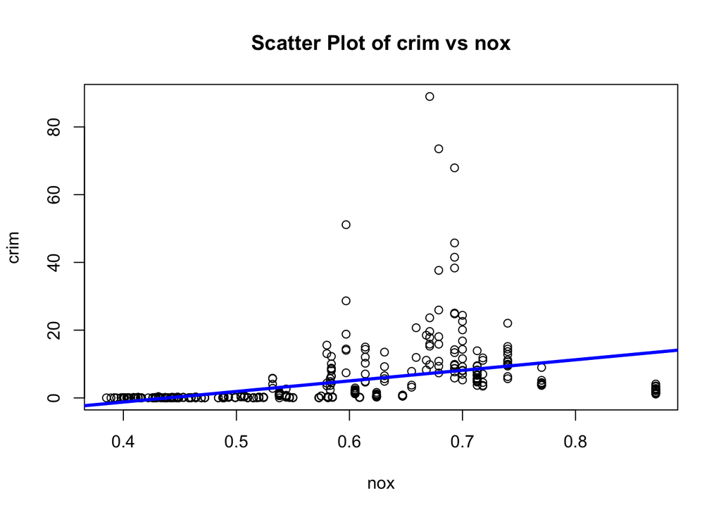

```r
attach(Boston)
plot(nox,crim, main="Scatter Plot of crim vs nox")
abline(lm.nox, lwd =3, col ="blue")
```

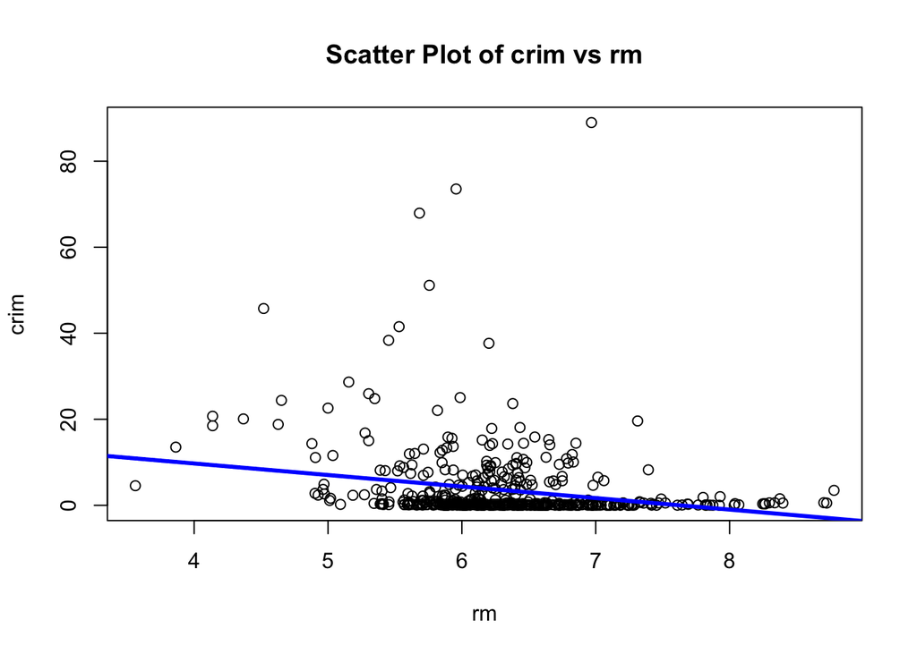

```r
plot(rm,crim, main="Scatter Plot of crim vs rm")
abline(lm.rm, lwd =3, col ="blue")
```

**(b)**

```r
# Regression using all predictors.
lm.fit_all = lm(crim~., data=Boston)
summary(lm.fit_all)
```

```
Call:
lm(formula = crim ~ ., data = Boston)

Residuals:
   Min     1Q Median     3Q    Max
-8.534 -2.248 -0.348  1.087 73.923

Coefficients:
              Estimate Std. Error t value Pr(>|t|)
(Intercept) 13.7783938  7.0818258   1.946 0.052271 .
zn           0.0457100  0.0187903   2.433 0.015344 *
indus       -0.0583501  0.0836351  -0.698 0.485709
chas        -0.8253776  1.1833963  -0.697 0.485841
nox         -9.9575865  5.2898242  -1.882 0.060370 .
rm           0.6289107  0.6070924   1.036 0.300738
age         -0.0008483  0.0179482  -0.047 0.962323
dis         -1.0122467  0.2824676  -3.584 0.000373 ***
rad          0.6124653  0.0875358   6.997 8.59e-12 ***
tax         -0.0037756  0.0051723  -0.730 0.465757
ptratio     -0.3040728  0.1863598  -1.632 0.103393
lstat        0.1388006  0.0757213   1.833 0.067398 .
medv        -0.2200564  0.0598240  -3.678 0.000261 ***
---
Signif. codes:  0 '***' 0.001 '**' 0.01 '*' 0.05 '.' 0.1 ' ' 1

Residual standard error: 6.46 on 493 degrees of freedom
Multiple R-squared:  0.4493,    Adjusted R-squared:  0.4359
F-statistic: 33.52 on 12 and 493 DF,  p-value: < 2.2e-16
```

**(c)**

- The coefficient estimates and statistical significance for predictors have changed. For example, `ptratio` has a negative coefficient here, whereas it had a positive one in simple regression. `nox` has a negative coefficient here, whereas it had a positive one in simple regression. In simple regression the coefficient of a predictor is calculated while ignoring all other predictors, but in multiple regression it is calculated while holding other predictors fixed. The difference in values between results from (a) and (b) isn’t contradictory if the variables have collinearity. This means that the variables are correlated with each other, and therefore the effect of one variable on the response is confounded by the effect of another variable. This is why the coefficients change when other predictors are added to the model.

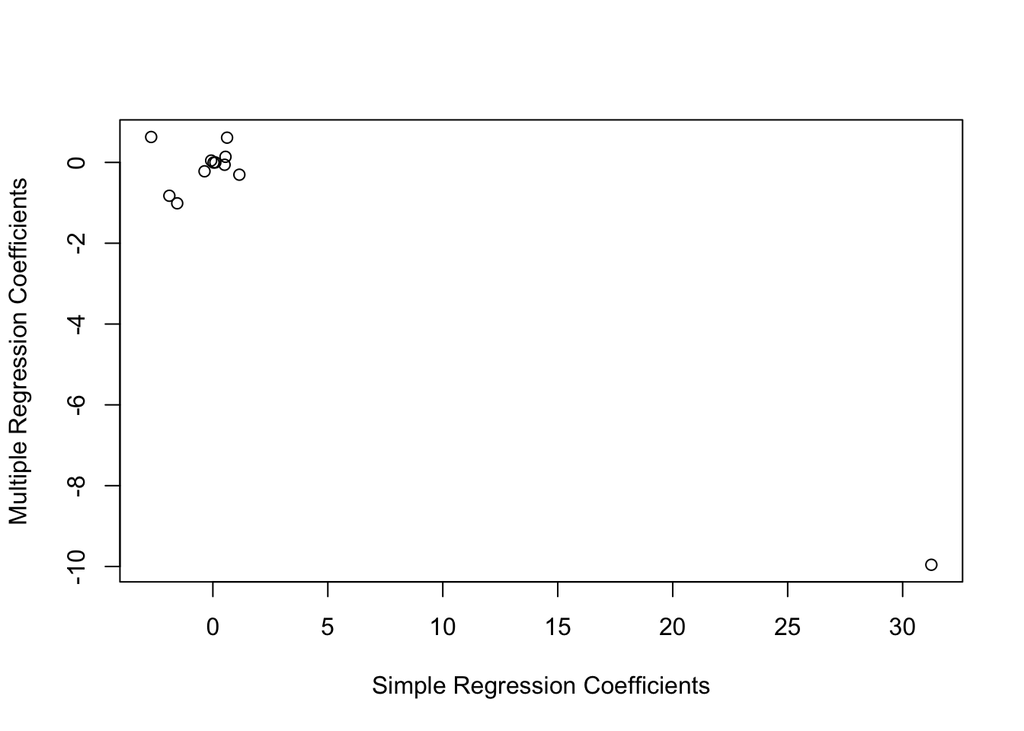

```r
# Dataframe with coefficients from multiple regression and an empty column for coefficients from simple regression.
df_coefs = data.frame("multi_coefs"=summary(lm.fit_all)$coef[-1,1]) # coef[-1,1] extracts the coefficients from a linear regression model. Exclude the first row and select the first column.
df_coefs$simple_coefs = NA

# Loop through each predictor, run linear regression and add values to dataframe.
for(i in row.names(df_coefs)){
    reg_model =  lm(crim~eval(str2lang(i)), data=Boston)
    df_coefs[row.names(df_coefs)==i, "simple_coefs"] = coef(reg_model)[2] # Intercept (coefficient 1); slope (coefficient 2)
}


# Plot chart.
plot(df_coefs$simple_coefs, df_coefs$multi_coefs, xlab="Simple Regression Coefficients", ylab="Multiple Regression Coefficients")
```

**(d)** Is there evidence of non-linear association between any of the predictors and the response? To answer this question, for each predictor X, fit a model of the form
$$Y = \beta_0 + \beta_1X + \beta_2X^2 + \beta_3X^3 + \epsilon.$$

```r
# Dataframe with columns for p-values of all polynomial terms.
df_poly = data.frame("variables"=names(Boston[2:13])) # a data frame with one column ("variables") that contains the names of predictor variables from columns 2 through 13 of the 'Boston' dataset.
df_poly$P_values_deg1 = NA
df_poly$P_values_deg2 = NA
df_poly$P_values_deg3 = NA

# Removed CHAS as it is a qualitative variable. It also caused error : 'degree' must be less than number of unique points.
df_poly = df_poly[-3,]
row.names(df_poly) <- NULL # Reset row numbers. This is done to ensure that row indices are consecutive after removing a row.


# Loop through variables, run polynomial regression and add p-values to dataframe.
# Regression formula created from strings of each variable combined using paste.
for(i in 1:11){
    frmla1 = paste("poly(",paste(df_poly$variables[i],3,sep=","),")",sep="")
    frmla2 = paste("crim",frmla1,sep="~")
    frmla3 = as.formula(frmla2)
    poly_model = lm(frmla3, data=Boston)
    summary(poly_model)$coefficients
    df_poly[i,2] = summary(poly_model)$coefficients[2,4]
    df_poly[i,3] = summary(poly_model)$coefficients[3,4]
    df_poly[i,4] = summary(poly_model)$coefficients[4,4]
}


df_poly
```

```
   variables P_values_deg1 P_values_deg2 P_values_deg3
1         zn  4.697806e-06  4.420507e-03  2.295386e-01
2      indus  8.854243e-24  1.086057e-03  1.196405e-12
3        nox  2.457491e-26  7.736755e-05  6.961110e-16
4         rm  5.128048e-07  1.508545e-03  5.085751e-01
5        age  4.878803e-17  2.291156e-06  6.679915e-03
6        dis  1.253249e-21  7.869767e-14  1.088832e-08
7        rad  1.053211e-56  9.120558e-03  4.823138e-01
8        tax  6.976314e-49  3.665348e-06  2.438507e-01
9    ptratio  1.565484e-11  2.405468e-03  6.300514e-03
10     lstat  1.678072e-27  3.780418e-02  1.298906e-01
11      medv  4.930818e-27  2.928577e-35  1.046510e-12
```

- The degree 1 coefficients are all statistically significant.
- The degree 2 (squared fit) coefficients are all statistically significant in general.
- The degree 3 (cubic fit) coefficients of indus, nox, age, dis, ptratio and medv are statistically significant in general.
- The p-values support a quadratic fit for all variables, and also support a cubic fit for medv, dis, age, nox, ptratio and indus. Therefore, there is evidence of a non-linear relationship (either quadratic or cubic) all variables.

## 7 Bonus question (20pts)

For multiple linear regression, show that $R^2$ is equal to the correlation between the response vector $\mathbf{y} = (y_1, \ldots, y_n)^T$ and the fitted values $\hat{\mathbf{y}} = (\hat y_1, \ldots, \hat y_n)^T$. That is
$$R^2 = 1 - \frac{\text{RSS}}{\text{TSS}} = [\operatorname{Cor}(\mathbf{y}, \hat{\mathbf{y}})]^2.$$

**Answer:**
$$\begin{align*}
R^2 &= 1 - \frac{\text{RSS}}{\text{TSS}} =\frac{\text{ESS}}{\text{TSS}} \\
&= \frac{\sum_{i=1}^n ( \hat y_i - \bar y)^2}{\sum_{i=1}^n (y_i - \bar y)^2} \\
\end{align*}$$
$$\begin{align*}
Cor(\mathbf{y}, \hat{\mathbf{y}}) &= \frac{Cov(\mathbf{y}, \hat{\mathbf{y}})}{\sigma_y \sigma_{\hat y}} \\
&= \frac{Cov(\mathbf{\hat{\mathbf{y}}+\epsilon}, \hat{\mathbf{y}})}{\sqrt{Var(\mathbf{y})} \sqrt{Var(\hat{\mathbf{y}})}} \\
&= \frac{Cov(\mathbf{\hat{\mathbf{y}}}, \hat{\mathbf{y}})+Cov(\epsilon, \hat{\mathbf{y}})}{\sqrt{Var(\mathbf{y})} \sqrt{Var(\hat{\mathbf{y}})}} \\
\end{align*}$$
$$\epsilon \perp \hat{\mathbf{y}} \\
Cov(\epsilon, \hat{\mathbf{y}}) = 0$$
$$\begin{align*}
Cor(\mathbf{y}, \hat{\mathbf{y}}) =\frac{Cov(\mathbf{\hat{\mathbf{y}}}, \hat{\mathbf{y}})}{\sqrt{Var(\mathbf{y})} \sqrt{Var(\hat{\mathbf{y}})}} \\
\end{align*}$$
$$\begin{align*}
Cor(\mathbf{y}, \hat{\mathbf{y}}) ^2 &=\frac{Cov(\mathbf{\hat{\mathbf{y}}}, \hat{\mathbf{y}})^2}{Var(\mathbf{y}) Var(\hat{\mathbf{y}})} \\
&= \frac{ Var(\hat{\mathbf{y}})^2 } {Var(\mathbf{y}) Var(\hat{\mathbf{y}})} \\
&= \frac{ Var(\hat{\mathbf{y}}) } {Var(\mathbf{y})} \\
&= \frac{ \sum_{i=1}^n ( \hat y_i - \bar y)^2 } {\sum_{i=1}^n (y_i - \bar y)^2} \\
\end{align*}$$

$$R^2 = 1 - \frac{\text{RSS}}{\text{TSS}} = [\operatorname{Cor}(\mathbf{y}, \hat{\mathbf{y}})]^2.$$